# Lab3

Xiaoxu Pan

2017/9/29

## Question 1

> The **Cars93** dataset in the **MASS** package contains data from 93 cars on sale in the USA in 1993. Randomly select 40 cars as the training dataset and the remaining 53 cars as the test dataset. Save both datasets as csv files. Find out the number of **USA** and **non-USA** cars in the training dataset.
- Training dataset

```
##     X  Manufacturer          Model    Type Min.Price Price Max.Price
## 1  70    Oldsmobile     Silhouette     Van      19.5  19.5      19.5
## 2  64        Nissan         Sentra   Small       8.7  11.8      14.9
## 3   8         Buick     Roadmaster   Large      22.6  23.7      24.9
## 4  17     Chevrolet          Astro     Van      14.7  16.6      18.6
## 5  34          Ford        Mustang  Sporty      10.8  15.9      21.0
## 6   4          Audi            100 Midsize      30.8  37.7      44.6
## 7  76       Pontiac     Grand_Prix Midsize      15.4  18.5      21.6
## 8  38          Ford Crown_Victoria   Large      20.1  20.9      21.7
## 9  18     Chevrolet        Caprice   Large      18.0  18.8      19.6
## 10 54         Mazda        Protege   Small      10.9  11.6      12.3
## 11 31          Ford        Festiva   Small       6.9   7.4       7.9
## 12 75       Pontiac       Firebird  Sporty      14.0  17.7      21.4
## 13 60       Mercury          Capri  Sporty      13.3  14.1      15.0
## 14 85        Toyota         Celica  Sporty      14.2  18.4      22.6
```

[output cut: 190 more lines]

- Test dataset

```
##     X  Manufacturer       Model    Type Min.Price Price Max.Price MPG.city
## 1   1         Acura     Integra   Small      12.9  15.9      18.8       25
## 2   2          Audi          90 Compact      25.9  29.1      32.3       20
## 3   3           BMW        535i Midsize      23.7  30.0      36.2       22
## 4   4         Buick     Century Midsize      14.2  15.7      17.3       22
## 5   5         Buick     LeSabre   Large      19.9  20.8      21.7       19
## 6   6         Buick     Riviera Midsize      26.3  26.3      26.3       19
## 7   7      Cadillac     Seville Midsize      37.5  40.1      42.7       16
## 8   8     Chevrolet    Cavalier Compact       8.5  13.4      18.3       25
## 9   9     Chevrolet     Corsica Compact      11.4  11.4      11.4       25
## 10 10     Chevrolet      Camaro  Sporty      13.4  15.1      16.8       19
## 11 11     Chevrolet  Lumina_APV     Van      14.7  16.3      18.0       18
## 12 12     Chevrolet    Corvette  Sporty      34.6  38.0      41.5       17
## 13 13      Chrylser    Concorde   Large      18.4  18.4      18.4       20
## 14 14      Chrysler     LeBaron Compact      14.5  15.8      17.1       23
```

[output cut: 255 more lines]

- Number of USA and non-USA cars in the training dataset

```
## [1] 19
```

```
## [1] 21
```

## Question 2

> Assume that the probabilities of boy and girl births are 0.515 and 0.485, respectively. Use the **sample()** function to simulate 10 births and print out the result. How many boys and girls do you get out of 10 births? Then simulate 10,000 births. How many boys and girls do you get out of 10,000 births?
- Result of 10 births

```
## Birth1
##  boy girl
##    9    1
```

```
##  [1] "boy"  "girl" "boy"  "boy"  "boy"  "boy"  "boy"  "boy"  "boy"  "boy"
```

- Result of 10000 births

```
## Birth2
##  boy girl
## 5176 4824
```

[output not shown]

[output cut: 1097 more lines]

## Question 3

> Assume that the probabilities of boy and girl births are 0.515 and 0.485, respectively. What’s the probability of having exactly 3 boys out of 10 births? What’s the probability of having 8 or more boys out of 10 births? Plot both the density function and cumulative probability function of the number of boy births out of 10.
- Probability of having exactly 3 boys out of 10 births

```
## [1] 0.1034654
```

- Probability of having 8 or more boys out of 10 births

```
## [1] 0.06605068
```

- Plot both the density function and cumulative probability function of the number of boy births out of 10

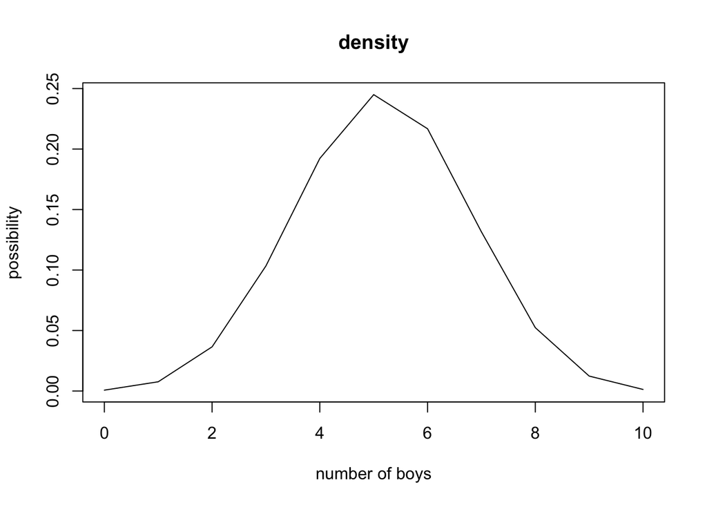

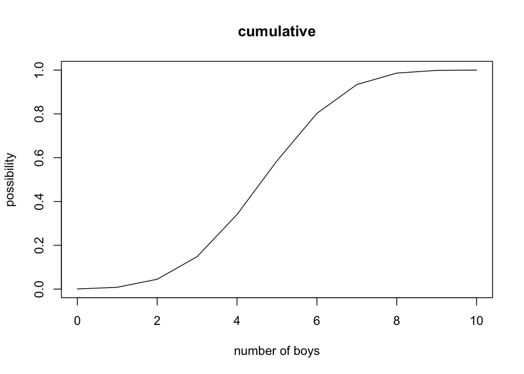

## Question 4

> If cars arrive randomly at a traffic light at the rate of five every ten seconds. What the probability that exactly four cars arrive in the next ten seconds? What’s the probability that more than five cars arrive in the next ten seconds? Plot the density function of 0-20 cars arriving in the next ten seconds
- Probability that exactly four cars arrive in the next ten seconds

```
## [1] 0.1754674
```

- Probability that more than five cars arrive in the next ten seconds

```
## [1] 0.3840393
```

- Plot the density function of 0-20 cars arriving in the next ten seconds

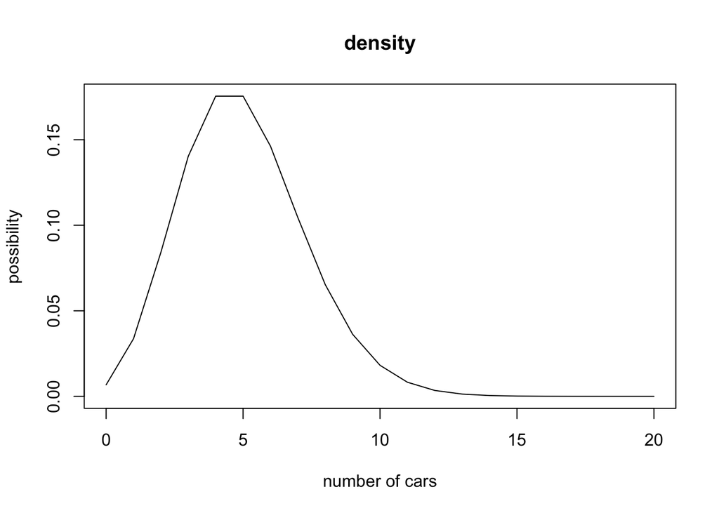